# Entrenamiento modelos

Olast Arrizibita Iriarte

22 de diciembre de 2021

El objetivo de este archivo sera el de crear distintos algoritmos para poder ver cual es el que mejores resultados nos depara.

Lo primero que haremos sera cargar los datos

```r
# FTR: Erantzun aldagaia da (H = Victoria local, D = Empate, A = Victoria visitante)
# HTR = Resultado del medio tiempo (H = Victoria local, D = Empate, A = Victoria visitante)

df1<- df %>% select(-Date, -Div, -HTR, -jornada_casa, -jornada_fuer)

df1<- df1 %>% select(-HomeTeam, -AwayTeam)

# Tenemos un valor que solo aparece una vez. por lo tanto lo tenemos que sustituir.
df1<- df1 %>% mutate(relati_tem_visit=ifelse(relati_tem_visit=="0", "1",relati_tem_visit))

# table(df$FTR)
#    A    D    H
# 1726 1493 2861

df1$FTR<- factor(df1$FTR, levels = c("H", "D", "A"))
```

```r
sumar<- function(x){
  x<- x+1
  return(x)
}

df_modi<- df1 %>% mutate_at(c(24:88), sumar)


df_modi<- df_modi %>% mutate(cant_no_gana=cant_no_gana_casa_local/cant_no_gana_fuera_visit,
                         cant_no_gana_abs=cant_no_gana_abso_local/cant_no_gana_abso_visit,
                         cant_gana=cant_gana_casa_local/cant_gana_fuera_visit,
                         cant_gana_abso=cant_gana_abso_local/cant_gana_abso_visit,
                         cant_perd=cant_perd_casa_local/cant_perd_fuera_visit,
                         cant_perd_abso=cant_perd_abso_local/cant_perd_abso_visit,
                         posicion_final=posicion_final_local/posicion_final_visit,
                         acumu_5part=acumu_5part_local/acumu_5part_visit,
                         acumu_5part_abso=acumu_5part_local_abso/acumu_5part_visit_abso,
                         acumu_enc3gol=acumu_enc3gol_local/acumu_enc3gol_visit,
                         acumu_enc3gol_abso=acumu_enc3gol_local_abso/acumu_enc3gol_visit_abso,
                         acumu_reali3gol=acumu_reali3gol_local/acumu_reali3gol_visit,
                         acumu_reali3gol_abso=acumu_reali3gol_local_abso/acumu_reali3gol_visit_abso,
                         acumu_enc3gol_media=acumu_enc3gol_media_local/acumu_enc3gol_media_visit,
                         acumu_enc3gol_media_abso=acumu_enc3gol_media_local_abso/acumu_enc3gol_media_visit_abso,
                         acumu_reali3gol_media=acumu_reali3gol_media_local/acumu_reali3gol_media_visit,
                         acumu_reali3gol_media_abso=acumu_reali3gol_media_local_abso/acumu_reali3gol_media_visit_abso,
                         mejor_racha=mejor_racha_loca/mejor_racha_visit,
                         mejor_racha_abso=mejor_racha_abso_local/mejor_racha_abso_visit,
                         peor_racha=peor_racha_loca/peor_racha_visit,
                         peor_racha_abso=peor_racha_abso_local/peor_racha_abso_visit,
                         gol_ante=gol_ante_local/gol_ante_visi,
                         gol_ante_abso=gol_ante_local_abso/gol_ante_visi_abso,
                         resul_ante=resul_ante_local/resul_ante_visi,
                         resul_ante_abso=resul_ante_local_abso/resul_ante_visi_abso,
                         disp_ante=disp_ante_local/disp_ante_visi,
                         disp_ante_abso=disp_ante_local_abso/disp_ante_visi_abso,
                         disp_puer_ante=disp_puer_ante_local/disp_puer_ante_visi,
                         disp_puer_ante_abso=disp_puer_ante_local_abso/disp_puer_ante_visi_abso,
                         roj_ante=roj_ante_local/roj_ante_visi,
                         roj_ante_abso=roj_ante_local_abso/roj_ante_visi_abso)


df_modi1<- df_modi %>% select(FTR, B365H, B365D, B365A, BWH, BWD, BWA, IWH, IWD, IWA, WHH, WHD, WHA, VCH,
                             VCD, VCA, tmed_local, prec_local, racha_local, sol_local, relati_tem_local,
                             relati_sol_local, relati_tem_visit, relati_sol_visit, diff_temp_med,
                             diff_lluvia_sum, diff_sol_med, cant_no_gana, cant_no_gana_abs, cant_gana,
                             cant_gana_abso, cant_perd, cant_perd_abso, posicion_final, acumu_5part,
                             acumu_5part_abso, acumu_enc3gol, acumu_enc3gol_abso, acumu_reali3gol,
                             acumu_reali3gol_abso, acumu_enc3gol_media, acumu_enc3gol_media_abso,
                             acumu_reali3gol_media, acumu_reali3gol_media_abso, mejor_racha, mejor_racha_abso,
                             peor_racha, peor_racha_abso, gol_ante, gol_ante_abso, resul_ante, resul_ante_abso,
                             disp_ante, disp_ante_abso, disp_puer_ante, disp_puer_ante_abso, roj_ante, roj_ante_abso)



df_modi2<- df_modi %>% select(-B365H, -B365D, -B365A, -BWH, -BWD, -BWA, -IWH, -IWD, -IWA, -WHH, -WHD, -WHA, -VCH,
                             -VCD, -VCA, -tmed_local, -prec_local, -racha_local, -sol_local, -relati_tem_local,
                             -relati_sol_local, -relati_tem_visit, -relati_sol_visit, -diff_temp_med,
                             -diff_lluvia_sum, -diff_sol_med)


df_modi3<- df_modi %>% select(FTR, B365H, B365D, B365A, BWH, BWD, BWA, IWH, IWD, IWA, WHH, WHD, WHA, VCH,VCD,
                              VCA, apues_derr_loc, apues_vict_loc,apues_empa_loc)


df_modi4<- df_modi %>% select(-tmed_local, -prec_local, -racha_local, -sol_local, -relati_tem_local,
                             -relati_sol_local, -relati_tem_visit, -relati_sol_visit, -diff_temp_med,
                             -diff_lluvia_sum, -diff_sol_med)



df_modi5<- df_modi %>% select(FTR, tmed_local, prec_local, racha_local, sol_local, relati_tem_local,
                             relati_sol_local, relati_tem_visit, relati_sol_visit, diff_temp_med,
                             diff_lluvia_sum, diff_sol_med, cant_no_gana, cant_no_gana_abs, cant_gana,
                             cant_gana_abso, cant_perd, cant_perd_abso, posicion_final, acumu_5part,
                             acumu_5part_abso, acumu_enc3gol, acumu_enc3gol_abso, acumu_reali3gol,
                             acumu_reali3gol_abso, acumu_enc3gol_media, acumu_enc3gol_media_abso,
                             acumu_reali3gol_media, acumu_reali3gol_media_abso, mejor_racha, mejor_racha_abso,
                             peor_racha, peor_racha_abso, gol_ante, gol_ante_abso, resul_ante, resul_ante_abso,
                             disp_ante, disp_ante_abso, disp_puer_ante, disp_puer_ante_abso, roj_ante, roj_ante_abso)


df_modi6<- df_modi %>% select(FTR, tmed_local, prec_local, racha_local, sol_local, relati_tem_local,
                             relati_sol_local, relati_tem_visit, relati_sol_visit, diff_temp_med,
                             diff_lluvia_sum, diff_sol_med, B365H, B365D, B365A, BWH, BWD, BWA, IWH, IWD,
                             IWA, WHH, WHD, WHA, VCH,VCD, VCA, apues_derr_loc, apues_vict_loc,apues_empa_loc)
```

# 1 Random forest

## 1.1 Todas las variables

Vamos a empezar creando un modelo Random forest. Para ello vamos utilizar distintos caminos. Para empezar utilizaremos el camino mas convencional y correcto. Entrenaremos el modelo con las tres categorías de las que consta. Ganar, empatar y perder.

### 1.1.1 Victoria, empate, derrota

Empezamos con el camino mas directo y correcto. Para intentar conseguir los mejores hiperparametros utilizaremos una optimización bayesiana.

```r
BBDD<- data.frame(df1)


# scoring_function1 <- function(N, M, V=1, k=15) {
#   require(dplyr)
#   require(parsnip)
#   folds = createFolds(BBDD[,V], k = k)
#   cv = lapply(folds, function(x) {
#     training_fold = BBDD[-x, ]
#     test_fold = BBDD[x, ]
#     classifier = parsnip::rand_forest(mode  = "classification",
#                              mtry  = M,
#                              trees = N)
#     classifier <- classifier %>% fit(FTR~.,data=training_fold)
#     y_pred = predict(classifier, new_data = test_fold[,-V])
#
#     cm = table(test_fold[, V], y_pred$.pred_class)
#     print(cm)
#     accuracy = (cm[1,1]+cm[2,2]+cm[3,3])/(cm[1,1]+cm[1,2]+cm[1,3]+cm[2,1]+
#                                             cm[2,2]+cm[2,3]+cm[3,1]+cm[3,2]+cm[3,3])
#     return(accuracy)
#
#   })
#   accuracy = mean(as.numeric(cv))
#   return(list(Score = accuracy))
# }
#
# limites <- list(
#   N= c(1L, 1000L),
#   M= c(1L, 98L)
#   # P= c(0L, 1L) TRUE edo FALSE kasurako
# )
#
# library("ParBayesianOptimization")
# library(doParallel)
#
# cl <- makeCluster(5)
# registerDoParallel(cl)
# clusterExport(cl,c('BBDD'))
# clusterEvalQ(cl,expr= {
#   c(library(e1071),
#     library(caret),
#     library(caTools),
#     library(randomForest))
#   })
#
# optObj <- bayesOpt(
#       FUN = scoring_function1
#       , bounds = limites
#       , initPoints = 5
#       , iters.n = 10
#       , iters.k = 1
#       , parallel = TRUE
#       , acq="ei"
#     )
#
# stopCluster(cl)
# registerDoSEQ()
```

Entrenamos el modelo.

```r
BBDD<- data.frame(df1)

folds = createFolds(BBDD[,1], k = 20)
training_fold = BBDD[-folds$Fold20, ]
test_fold = BBDD[folds$Fold20, ]


rf1 <-rand_forest(mode  = "classification",
                  mtry  = 35,
                  trees = 621)

rf1<- rf1 %>%
          set_engine(
            engine     = "ranger",
            importance = "impurity",
            seed       = 123
          )

rf1<- rf1 %>% fit(FTR~.,data=training_fold)

## TRAIN

y_pred = predict(rf1, new_data = training_fold[,-1])

cm<- table(y_pred$.pred_class, training_fold$FTR)
ACC_TRAIN<- (cm[1,1]+cm[2,2]+cm[3,3])/(cm[1,1]+cm[1,2]+cm[1,3]+cm[2,1]+cm[2,2]+cm[2,3]+cm[3,1]+cm[3,2]+cm[3,3])
print(paste("Final Accuracy TRAIN =",sprintf("%1.2f%%", 100*ACC_TRAIN)))
```

```
## [1] "Final Accuracy TRAIN = 99.43%"
```

```r
## TEST

y_pred = predict(rf1, new_data = test_fold[,-1])

cm<- table(y_pred$.pred_class, test_fold$FTR)
ACC_Test<- (cm[1,1]+cm[2,2]+cm[3,3])/(cm[1,1]+cm[1,2]+cm[1,3]+cm[2,1]+cm[2,2]+cm[2,3]+cm[3,1]+cm[3,2]+cm[3,3])

print(paste("Final Accuracy TEST =",sprintf("%1.2f%%", 100*ACC_Test)))
```

```
## [1] "Final Accuracy TEST = 55.26%"
```

Visto que el resultado no es el mejor. Estamos interesados en ver cuales son las variables que mas influyen en el modelo. Para luego solamente con ellas hacer un modelo nuevo con la esperanza de que el accuracy se incremente.

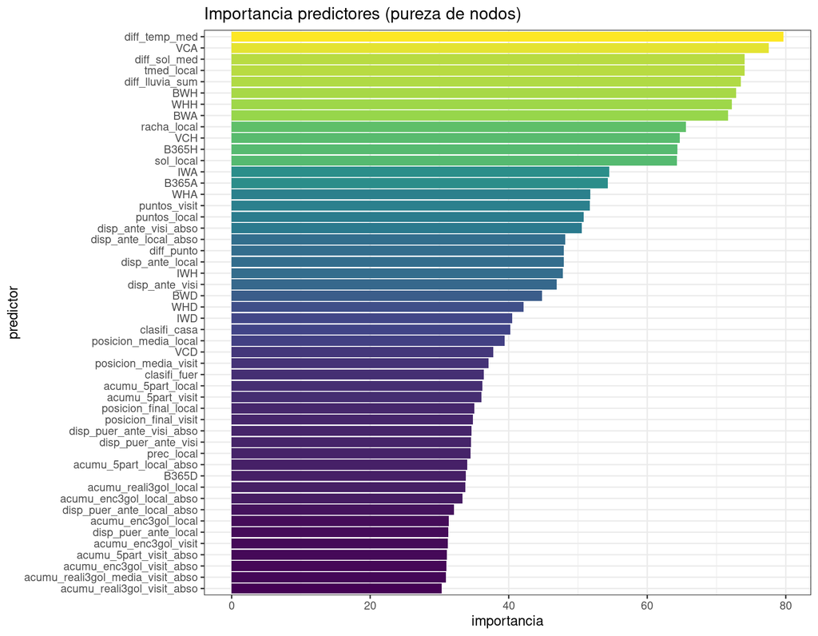

Tal como hemos dicho seleccionamos las variables que mas influyen

```r
# PREPETIMOS EL PROCESO

BBDD<- data.frame(df1[c("FTR", importancia_pred_aa$predictor)])


# scoring_function1 <- function(N, M, V=1, k=6) {
#   require(dplyr)
#   require(parsnip)
#   folds = createFolds(BBDD[,V], k = k)
#   cv = lapply(folds, function(x) {
#     training_fold = BBDD[-x, ]
#     test_fold = BBDD[x, ]
#     # classifier = randomForest(x = training_fold[,-V],
#     #                         y = training_fold$micro_proteccion_celular,
#     #                         ntree = N,
#     #                         mtry=M, importance=TRUE,
#     #                         proximity=TRUE)
#     classifier = parsnip::rand_forest(mode  = "classification",
#                              mtry  = M,
#                              trees = N)
#     classifier <- classifier %>% fit(FTR~.,data=training_fold)
#     y_pred = predict(classifier, new_data = test_fold[,-V])
#
#     # cm = table(test_fold[, V], y_pred)
#     cm = table(test_fold[, V], y_pred$.pred_class)
#     print(cm)
#     accuracy = (cm[1,1]+cm[2,2]+cm[3,3])/(cm[1,1]+cm[1,2]+cm[1,3]+cm[2,1]+
#                                             cm[2,2]+cm[2,3]+cm[3,1]+cm[3,2]+cm[3,3])
#     return(accuracy)
#
#   })
#   accuracy = mean(as.numeric(cv))
#   return(list(Score = accuracy))
# }
#
# limites <- list(
#   N= c(1L, 4000L),
#   M= c(1L, 50L)
# )
#
# library("ParBayesianOptimization")
# library(doParallel)
#
# cl <- makeCluster(5)
# registerDoParallel(cl)
# clusterExport(cl,c('BBDD'))
# clusterEvalQ(cl,expr= {
#   c(library(e1071),
#     library(caret),
#     library(caTools),
#     library(randomForest))
#   })
#
# optObj <- bayesOpt(
#       FUN = scoring_function1
#       , bounds = limites
#       , initPoints = 5
#       , iters.n = 10
#       , iters.k = 1
#       , parallel = TRUE
#       , acq="ei"
#     )
#
# stopCluster(cl)
# registerDoSEQ()


folds = createFolds(BBDD[,1], k = 20)
training_fold2 = BBDD[-folds$Fold20, ]
test_fold2 = BBDD[folds$Fold20, ]
#
tem_var<- df["Div"][folds$Fold20, ]

rf1 <-rand_forest(mode  = "classification",
                  mtry  = 16,
                  trees = 916)

rf1<- rf1 %>%
          set_engine(
            engine     = "ranger",
            importance = "impurity",
            seed       = 123
          )

rf1<- rf1 %>% fit(FTR~.,data=training_fold2)

## TRAIN

y_pred = predict(rf1, new_data = training_fold2[,-1])

cm<- table(y_pred$.pred_class, training_fold2$FTR)
ACC_TRAIN<- (cm[1,1]+cm[2,2]+cm[3,3])/(cm[1,1]+cm[1,2]+cm[1,3]+cm[2,1]+cm[2,2]+cm[2,3]+cm[3,1]+cm[3,2]+cm[3,3])
print(paste("Final Accuracy TRAIN =",sprintf("%1.2f%%", 100*ACC_TRAIN)))
```

```
## [1] "Final Accuracy TRAIN = 99.12%"
```

```r
##  TEST

y_pred = predict(rf1, new_data = test_fold2[,-1])

cm<- table(y_pred$.pred_class, test_fold2$FTR)
ACC_TEST<- (cm[1,1]+cm[2,2]+cm[3,3])/(cm[1,1]+cm[1,2]+cm[1,3]+cm[2,1]+cm[2,2]+cm[2,3]+cm[3,1]+cm[3,2]+cm[3,3])
print(paste("Final Accuracy TEST =",sprintf("%1.2f%%", 100*ACC_TEST)))
```

```
## [1] "Final Accuracy TEST = 52.48%"
```

Tal como hemos dicho seleccionamos las variables que mas influyen

```r
BBDD<- data.frame(df1[c("FTR", importancia_pred_aa$predictor[1:19])])

# scoring_function1 <- function(N, M, V=1, k=30) {
#   require(dplyr)
#   require(parsnip)
#   # P=ifelse(P==0,FALSE,TRUE)
#   folds = createFolds(BBDD[,V], k = k)
#   cv = lapply(folds, function(x) {
#     training_fold = BBDD[-x, ]
#     test_fold = BBDD[x, ]
#     classifier = parsnip::rand_forest(mode  = "classification",
#                              mtry  = M,
#                              trees = N)
#     classifier <- classifier %>% fit(FTR~.,data=training_fold)
#     y_pred = predict(classifier, new_data = test_fold[,-V])
#
#     cm = table(test_fold[, V], y_pred$.pred_class)
#     print(cm)
#     accuracy = (cm[1,1]+cm[2,2]+cm[3,3])/(cm[1,1]+cm[1,2]+cm[1,3]+cm[2,1]+
#                                             cm[2,2]+cm[2,3]+cm[3,1]+cm[3,2]+cm[3,3])
#     return(accuracy)
#
#   })
#   accuracy = mean(as.numeric(cv))
#   return(list(Score = accuracy))
# }
#
# limites <- list(
#   N= c(1L, 3000L),
#   M= c(1L, 19L)
#   # P= c(0L, 1L) TRUE edo FALSE kasurako
# )
#
# library("ParBayesianOptimization")
# library(doParallel)
#
# cl <- makeCluster(5)
# registerDoParallel(cl)
# clusterExport(cl,c('BBDD'))
# clusterEvalQ(cl,expr= {
#   c(library(e1071),
#     library(caret),
#     library(caTools),
#     library(randomForest))
#   })
#
# optObj <- bayesOpt(
#       FUN = scoring_function1
#       , bounds = limites
#       , initPoints = 5
#       , iters.n = 10
#       , iters.k = 1
#       , parallel = TRUE
#       , acq="ei"
#     )
#
# stopCluster(cl)
# registerDoSEQ()


folds = createFolds(BBDD[,1], k = 20)
training_fold3 = BBDD[-folds$Fold20, ]
test_fold3 = BBDD[folds$Fold20, ]
#
tem_var<- df["Div"][folds$Fold3, ]

rf1 <-rand_forest(mode  = "classification",
                  mtry  = 1,
                  trees = 2137)

rf1<- rf1 %>%
          set_engine(
            engine     = "ranger",
            importance = "impurity",
            seed       = 123
          )

rf1<- rf1 %>% fit(FTR~.,data=training_fold3)

## TRAIN

y_pred = predict(rf1, new_data = training_fold3[,-1])

cm<- table(y_pred$.pred_class, training_fold3$FTR)
ACC_TRAIN<- (cm[1,1]+cm[2,2]+cm[3,3])/(cm[1,1]+cm[1,2]+cm[1,3]+cm[2,1]+cm[2,2]+cm[2,3]+cm[3,1]+cm[3,2]+cm[3,3])
print(paste("Final Accuracy TRAIN =",sprintf("%1.2f%%", 100*ACC_TRAIN)))
```

```
## [1] "Final Accuracy TRAIN = 95.89%"
```

```r
## TEST

y_pred = predict(rf1, new_data = test_fold3[,-1])

cm<- table(y_pred$.pred_class, test_fold3$FTR)
ACC_TEST<- (cm[1,1]+cm[2,2]+cm[3,3])/(cm[1,1]+cm[1,2]+cm[1,3]+cm[2,1]+cm[2,2]+cm[2,3]+cm[3,1]+cm[3,2]+cm[3,3])
print(paste("Final Accuracy TEST =",sprintf("%1.2f%%", 100*ACC_TEST)))
```

```
## [1] "Final Accuracy TEST = 53.47%"
```

Utilizamos solamente las 10 que mas influyen

```r
BBDD<- data.frame(df1[c("FTR", importancia_pred_aa$predictor[1:10])])

# scoring_function1 <- function(N, M, V=1, k=6) {
#   require(dplyr)
#   require(parsnip)
#   # P=ifelse(P==0,FALSE,TRUE)
#   folds = createFolds(BBDD[,V], k = k)
#   cv = lapply(folds, function(x) {
#     training_fold = BBDD[-x, ]
#     test_fold = BBDD[x, ]
#     classifier = parsnip::rand_forest(mode  = "classification",
#                              mtry  = M,
#                              trees = N)
#     classifier <- classifier %>% fit(FTR~.,data=training_fold)
#     y_pred = predict(classifier, new_data = test_fold[,-V])
#
#     cm = table(test_fold[, V], y_pred$.pred_class)
#     print(cm)
#     accuracy = (cm[1,1]+cm[2,2]+cm[3,3])/(cm[1,1]+cm[1,2]+cm[1,3]+cm[2,1]+
#                                             cm[2,2]+cm[2,3]+cm[3,1]+cm[3,2]+cm[3,3])
#     return(accuracy)
#
#   })
#   accuracy = mean(as.numeric(cv))
#   return(list(Score = accuracy))
# }
#
# limites <- list(
#   N= c(1L, 1500L),
#   M= c(1L, 9L)
#   # P= c(0L, 1L) TRUE edo FALSE kasurako
# )
#
# library("ParBayesianOptimization")
# library(doParallel)
#
# cl <- makeCluster(5)
# registerDoParallel(cl)
# clusterExport(cl,c('BBDD'))
# clusterEvalQ(cl,expr= {
#   c(library(e1071),
#     library(caret),
#     library(caTools),
#     library(randomForest))
#   })
#
# optObj <- bayesOpt(
#       FUN = scoring_function1
#       , bounds = limites
#       , initPoints = 5
#       , iters.n = 10
#       , iters.k = 1
#       , parallel = TRUE
#       , acq="ei"
#     )
#
# stopCluster(cl)
# registerDoSEQ()


folds = createFolds(BBDD[,1], k = 20)
training_fold4 = BBDD[-folds$Fold20, ]
test_fold4 = BBDD[folds$Fold20, ]
#
tem_var<- df["Div"][folds$Fold20, ]

rf1 <-rand_forest(mode  = "classification",
                  mtry  = 1,
                  trees = 726)

rf1<- rf1 %>%
          set_engine(
            engine     = "ranger",
            importance = "impurity",
            seed       = 123
          )

rf1<- rf1 %>% fit(FTR~.,data=training_fold4)

## TRAIN

y_pred = predict(rf1, new_data = training_fold4[,-1])

cm<- table(y_pred$.pred_class, training_fold4$FTR)
ACC_TRAIN<- (cm[1,1]+cm[2,2]+cm[3,3])/(cm[1,1]+cm[1,2]+cm[1,3]+cm[2,1]+cm[2,2]+cm[2,3]+cm[3,1]+cm[3,2]+cm[3,3])
print(paste("Final Accuracy TRAIN =",sprintf("%1.2f%%", 100*ACC_TRAIN)))
```

```
## [1] "Final Accuracy TRAIN = 89.61%"
```

```r
## TEST

y_pred = predict(rf1, new_data = test_fold4[,-1])

cm<- table(y_pred$.pred_class, test_fold4$FTR)
ACC_TEST<- (cm[1,1]+cm[2,2]+cm[3,3])/(cm[1,1]+cm[1,2]+cm[1,3]+cm[2,1]+cm[2,2]+cm[2,3]+cm[3,1]+cm[3,2]+cm[3,3])
print(paste("Final Accuracy TEST =",sprintf("%1.2f%%", 100*ACC_TEST)))
```

```
## [1] "Final Accuracy TEST = 51.32%"
```

## 1.2 Variables derivadas y seleccionadas

las variables seleccionados son las que provienen de las estadisticas de los partidos de futbol y las que hemos derivados de estas haciendo una división (las bases de datos que empiezan por “df_modi”).

### 1.2.1 Derivadas partidos, partidos, apuestas y tiempo

```r
# BBDD<- data.frame(df_modi)
#
#
# scoring_function21 <- function(N, M, V=1, k=6) {
#   require(dplyr)
#   require(parsnip)
#   # P=ifelse(P==0,FALSE,TRUE)
#   folds = createFolds(BBDD[,V], k = k)
#   cv = lapply(folds, function(x) {
#     training_fold = BBDD[-x, ]
#     test_fold = BBDD[x, ]
#     classifier = parsnip::rand_forest(mode  = "classification",
#                              mtry  = M,
#                              trees = N) # BERRIA
#     classifier <- classifier %>% fit(FTR~.,data=training_fold) # BERRIA
#     y_pred = predict(classifier, new_data = test_fold[,-V]) # BERRIA
#
#     cm = table(test_fold[, V], y_pred$.pred_class) # BERRIA
#     print(cm)
#     accuracy = (cm[1,1]+cm[2,2]+cm[3,3])/(cm[1,1]+cm[1,2]+cm[1,3]+cm[2,1]+
#                                             cm[2,2]+cm[2,3]+cm[3,1]+cm[3,2]+cm[3,3])
#     return(accuracy)
#
#   })
#   accuracy = mean(as.numeric(cv))
#   return(list(Score = accuracy))
# }
#
# limites <- list(
#   N= c(1L, 1000L),
#   M= c(1L, 57L)
#   # P= c(0L, 1L) TRUE edo FALSE kasurako
# )
#
# library("ParBayesianOptimization")
# library(doParallel)
#
# cl <- makeCluster(5)
# registerDoParallel(cl)
# clusterExport(cl,c('BBDD'))
# clusterEvalQ(cl,expr= {
#   c(library(e1071),
#     library(caret),
#     library(caTools),
#     library(randomForest))
#   })
#
# optObj <- bayesOpt(
#       FUN = scoring_function21
#       , bounds = limites
#       , initPoints = 5
#       , iters.n = 10
#       , iters.k = 1
#       , parallel = TRUE
#       , acq="ei"
#     )
#
# stopCluster(cl)
# registerDoSEQ()
```

Entrenamos el modelo.

```r
BBDD<- data.frame(df_modi)

folds = createFolds(BBDD[,1], k = 20)
training_fold = BBDD[-folds$Fold20, ]
test_fold = BBDD[folds$Fold20, ]


rf1 <-rand_forest(mode  = "classification",
                  mtry  = 1,
                  trees = 185)

rf1<- rf1 %>%
          set_engine(
            engine     = "ranger",
            importance = "impurity",
            seed       = 123
          )

rf1<- rf1 %>% fit(FTR~.,data=training_fold)

## TRAIN

y_pred = predict(rf1, new_data = training_fold[,-1])

cm<- table(y_pred$.pred_class, training_fold$FTR)
ACC_TRAIN<- (cm[1,1]+cm[2,2]+cm[3,3])/(cm[1,1]+cm[1,2]+cm[1,3]+cm[2,1]+cm[2,2]+cm[2,3]+cm[3,1]+cm[3,2]+cm[3,3])
print(paste("Final Accuracy TRAIN =",sprintf("%1.2f%%", 100*ACC_TRAIN)))
```

```
## [1] "Final Accuracy TRAIN = 92.84%"
```

```r
## TEST

y_pred = predict(rf1, new_data = test_fold[,-1])

cm<- table(y_pred$.pred_class, test_fold$FTR)
ACC_TEST<- (cm[1,1]+cm[2,2]+cm[3,3])/(cm[1,1]+cm[1,2]+cm[1,3]+cm[2,1]+cm[2,2]+cm[2,3]+cm[3,1]+cm[3,2]+cm[3,3])
print(paste("Final Accuracy TEST =",sprintf("%1.2f%%", 100*ACC_TEST)))
```

```
## [1] "Final Accuracy TEST = 54.46%"
```

### 1.2.2 Derivadas partidos y partidos

```r
# BBDD<- data.frame(df_modi2)
#
#
# scoring_function31 <- function(N, M, V=1, k=6) {
#   require(dplyr)
#   require(parsnip)
#   # P=ifelse(P==0,FALSE,TRUE)
#   folds = createFolds(BBDD[,V], k = k)
#   cv = lapply(folds, function(x) {
#     training_fold = BBDD[-x, ]
#     test_fold = BBDD[x, ]
#     classifier = parsnip::rand_forest(mode  = "classification",
#                              mtry  = M,
#                              trees = N) # BERRIA
#     classifier <- classifier %>% fit(FTR~.,data=training_fold) # BERRIA
#     y_pred = predict(classifier, new_data = test_fold[,-V]) # BERRIA
#
#     cm = table(test_fold[, V], y_pred$.pred_class) # BERRIA
#     print(cm)
#     accuracy = (cm[1,1]+cm[2,2]+cm[3,3])/(cm[1,1]+cm[1,2]+cm[1,3]+cm[2,1]+
#                                             cm[2,2]+cm[2,3]+cm[3,1]+cm[3,2]+cm[3,3])
#     return(accuracy)
#
#   })
#   accuracy = mean(as.numeric(cv))
#   return(list(Score = accuracy))
# }
#
# limites <- list(
#   N= c(1L, 1000L),
#   M= c(1L, 103L)
#   # P= c(0L, 1L) TRUE edo FALSE kasurako
# )
#
# library("ParBayesianOptimization")
# library(doParallel)
#
# cl <- makeCluster(5)
# registerDoParallel(cl)
# clusterExport(cl,c('BBDD'))
# clusterEvalQ(cl,expr= {
#   c(library(e1071),
#     library(caret),
#     library(caTools),
#     library(randomForest))
#   })
#
# optObj <- bayesOpt(
#       FUN = scoring_function31
#       , bounds = limites
#       , initPoints = 5
#       , iters.n = 10
#       , iters.k = 1
#       , parallel = TRUE
#       , acq="ei"
#     )
#
# stopCluster(cl)
# registerDoSEQ()
```

Entrenamos el modelo.

```r
BBDD<- data.frame(df_modi2)

folds = createFolds(BBDD[,1], k = 10)
training_fold = BBDD[-folds$Fold10, ]
test_fold = BBDD[folds$Fold10, ]


rf1 <-rand_forest(mode  = "classification",
                  mtry  = 103,
                  trees = 561)

rf1<- rf1 %>%
          set_engine(
            engine     = "ranger",
            importance = "impurity",
            seed       = 123
          )

rf1<- rf1 %>% fit(FTR~.,data=training_fold)

## TRAIN

y_pred = predict(rf1, new_data = training_fold[,-1])

cm<- table(y_pred$.pred_class, training_fold$FTR)
ACC_TRAIN<- (cm[1,1]+cm[2,2]+cm[3,3])/(cm[1,1]+cm[1,2]+cm[1,3]+cm[2,1]+cm[2,2]+cm[2,3]+cm[3,1]+cm[3,2]+cm[3,3])
print(paste("Final Accuracy TRAIN =",sprintf("%1.2f%%", 100*ACC_TRAIN)))
```

```
## [1] "Final Accuracy TRAIN = 99.60%"
```

```r
## TEST

y_pred = predict(rf1, new_data = test_fold[,-1])

cm<- table(y_pred$.pred_class, test_fold$FTR)
ACC_TEST<- (cm[1,1]+cm[2,2]+cm[3,3])/(cm[1,1]+cm[1,2]+cm[1,3]+cm[2,1]+cm[2,2]+cm[2,3]+cm[3,1]+cm[3,2]+cm[3,3])
print(paste("Final Accuracy TEST =",sprintf("%1.2f%%", 100*ACC_TEST)))
```

```
## [1] "Final Accuracy TEST = 52.97%"
```

### 1.2.3 Apuestas

```r
# BBDD<- data.frame(df_modi3)
#
#
# scoring_function41 <- function(N, M, V=1, k=6) {
#   require(dplyr)
#   require(parsnip)
#   # P=ifelse(P==0,FALSE,TRUE)
#   folds = createFolds(BBDD[,V], k = k)
#   cv = lapply(folds, function(x) {
#     training_fold = BBDD[-x, ]
#     test_fold = BBDD[x, ]
#     classifier = parsnip::rand_forest(mode  = "classification",
#                              mtry  = M,
#                              trees = N)
#     classifier <- classifier %>% fit(FTR~.,data=training_fold)
#     y_pred = predict(classifier, new_data = test_fold[,-V])
#
#     cm = table(test_fold[, V], y_pred$.pred_class)
#     print(cm)
#     accuracy = (cm[1,1]+cm[2,2]+cm[3,3])/(cm[1,1]+cm[1,2]+cm[1,3]+cm[2,1]+
#                                             cm[2,2]+cm[2,3]+cm[3,1]+cm[3,2]+cm[3,3])
#     return(accuracy)
#
#   })
#   accuracy = mean(as.numeric(cv))
#   return(list(Score = accuracy))
# }
#
# limites <- list(
#   N= c(1L, 1000L),
#   M= c(1L, 18L)
#   # P= c(0L, 1L) TRUE edo FALSE kasurako
# )
#
# library("ParBayesianOptimization")
# library(doParallel)
#
# cl <- makeCluster(5)
# registerDoParallel(cl)
# clusterExport(cl,c('BBDD'))
# clusterEvalQ(cl,expr= {
#   c(library(e1071),
#     library(caret),
#     library(caTools),
#     library(randomForest))
#   })
#
# optObj <- bayesOpt(
#       FUN = scoring_function41
#       , bounds = limites
#       , initPoints = 5
#       , iters.n = 10
#       , iters.k = 1
#       , parallel = TRUE
#       , acq="ei"
#     )
#
# stopCluster(cl)
# registerDoSEQ()
```

Entrenamos el modelo.

```r
BBDD<- data.frame(df_modi3)

folds = createFolds(BBDD[,1], k = 20)
training_fold = BBDD[-folds$Fold20, ]
test_fold = BBDD[folds$Fold20, ]


rf1 <-rand_forest(mode  = "classification",
                  mtry  = 1,
                  trees = 445)

rf1<- rf1 %>%
          set_engine(
            engine     = "ranger",
            importance = "impurity",
            seed       = 123
          )

rf1<- rf1 %>% fit(FTR~.,data=training_fold)

## TRAIN

y_pred = predict(rf1, new_data = training_fold[,-1])

cm<- table(y_pred$.pred_class, training_fold$FTR)
ACC_TRAIN<- (cm[1,1]+cm[2,2]+cm[3,3])/(cm[1,1]+cm[1,2]+cm[1,3]+cm[2,1]+cm[2,2]+cm[2,3]+cm[3,1]+cm[3,2]+cm[3,3])
print(paste("Final Accuracy TRAIN =",sprintf("%1.2f%%", 100*ACC_TRAIN)))
```

```
## [1] "Final Accuracy TRAIN = 74.94%"
```

```r
## TEST

y_pred = predict(rf1, new_data = test_fold[,-1])

cm<- table(y_pred$.pred_class, test_fold$FTR)
ACC_TEST<- (cm[1,1]+cm[2,2]+cm[3,3])/(cm[1,1]+cm[1,2]+cm[1,3]+cm[2,1]+cm[2,2]+cm[2,3]+cm[3,1]+cm[3,2]+cm[3,3])
print(paste("Final Accuracy TEST =",sprintf("%1.2f%%", 100*ACC_TEST)))
```

```
## [1] "Final Accuracy TEST = 51.49%"
```

### 1.2.4 Derivadas partidos, partidos y apuestas

```r
# BBDD<- data.frame(df_modi4)
#
#
# scoring_function51 <- function(N, M, V=1, k=6) {
#   require(dplyr)
#   require(parsnip)
#   folds = createFolds(BBDD[,V], k = k)
#   cv = lapply(folds, function(x) {
#     training_fold = BBDD[-x, ]
#     test_fold = BBDD[x, ]
#     classifier = parsnip::rand_forest(mode  = "classification",
#                              mtry  = M,
#                              trees = N) # BERRIA
#     classifier <- classifier %>% fit(FTR~.,data=training_fold) # BERRIA
#     y_pred = predict(classifier, new_data = test_fold[,-V]) # BERRIA
#
#     cm = table(test_fold[, V], y_pred$.pred_class) # BERRIA
#     print(cm)
#     accuracy = (cm[1,1]+cm[2,2]+cm[3,3])/(cm[1,1]+cm[1,2]+cm[1,3]+cm[2,1]+
#                                             cm[2,2]+cm[2,3]+cm[3,1]+cm[3,2]+cm[3,3])
#     return(accuracy)
#
#   })
#   accuracy = mean(as.numeric(cv))
#   return(list(Score = accuracy))
# }
#
# limites <- list(
#   N= c(1L, 1000L),
#   M= c(1L, 118L)
#   # P= c(0L, 1L) TRUE edo FALSE kasurako
# )
#
# library("ParBayesianOptimization")
# library(doParallel)
#
# cl <- makeCluster(5)
# registerDoParallel(cl)
# clusterExport(cl,c('BBDD'))
# clusterEvalQ(cl,expr= {
#   c(library(e1071),
#     library(caret),
#     library(caTools),
#     library(randomForest))
#   })
#
# optObj <- bayesOpt(
#       FUN = scoring_function51
#       , bounds = limites
#       , initPoints = 5
#       , iters.n = 10
#       , iters.k = 1
#       , parallel = TRUE
#       , acq="ei"
#     )
#
# stopCluster(cl)
# registerDoSEQ()
```

Entrenamos el modelo.

```r
BBDD<- data.frame(df_modi4)

folds = createFolds(BBDD[,1], k = 20)
training_fold = BBDD[-folds$Fold20, ]
test_fold = BBDD[folds$Fold20, ]


rf1 <-rand_forest(mode  = "classification",
                  mtry  = 31,
                  trees = 339)

rf1<- rf1 %>%
          set_engine(
            engine     = "ranger",
            importance = "impurity",
            seed       = 123
          )

rf1<- rf1 %>% fit(FTR~.,data=training_fold)

## TRAIN

y_pred = predict(rf1, new_data = training_fold[,-1])

cm<- table(y_pred$.pred_class, training_fold$FTR)
ACC_TRAIN<- (cm[1,1]+cm[2,2]+cm[3,3])/(cm[1,1]+cm[1,2]+cm[1,3]+cm[2,1]+cm[2,2]+cm[2,3]+cm[3,1]+cm[3,2]+cm[3,3])
print(paste("Final Accuracy TRAIN =",sprintf("%1.2f%%", 100*ACC_TRAIN)))
```

```
## [1] "Final Accuracy TRAIN = 99.31%"
```

```r
## TEST

y_pred = predict(rf1, new_data = test_fold[,-1])

cm<- table(y_pred$.pred_class, test_fold$FTR)
ACC_TEST<- (cm[1,1]+cm[2,2]+cm[3,3])/(cm[1,1]+cm[1,2]+cm[1,3]+cm[2,1]+cm[2,2]+cm[2,3]+cm[3,1]+cm[3,2]+cm[3,3])
print(paste("Final Accuracy TEST =",sprintf("%1.2f%%", 100*ACC_TEST)))
```

```
## [1] "Final Accuracy TEST = 54.46%"
```

### 1.2.5 Derivadas partidos y meteorologia

```r
# BBDD<- data.frame(df_modi5)
#
#
# scoring_function61 <- function(N, M, V=1, k=6) {
#   require(dplyr)
#   require(parsnip)
#   folds = createFolds(BBDD[,V], k = k)
#   cv = lapply(folds, function(x) {
#     training_fold = BBDD[-x, ]
#     test_fold = BBDD[x, ]
#     classifier = parsnip::rand_forest(mode  = "classification",
#                              mtry  = M,
#                              trees = N) # BERRIA
#     classifier <- classifier %>% fit(FTR~.,data=training_fold) # BERRIA
#     y_pred = predict(classifier, new_data = test_fold[,-V]) # BERRIA
#
#     cm = table(test_fold[, V], y_pred$.pred_class) # BERRIA
#     print(cm)
#     accuracy = (cm[1,1]+cm[2,2]+cm[3,3])/(cm[1,1]+cm[1,2]+cm[1,3]+cm[2,1]+
#                                             cm[2,2]+cm[2,3]+cm[3,1]+cm[3,2]+cm[3,3])
#     return(accuracy)
#
#   })
#   accuracy = mean(as.numeric(cv))
#   return(list(Score = accuracy))
# }
#
# limites <- list(
#   N= c(1L, 1500L),
#   M= c(1L, 42L)
#   # P= c(0L, 1L) TRUE edo FALSE kasurako
# )
#
# library("ParBayesianOptimization")
# library(doParallel)
#
# cl <- makeCluster(5)
# registerDoParallel(cl)
# clusterExport(cl,c('BBDD'))
# clusterEvalQ(cl,expr= {
#   c(library(e1071),
#     library(caret),
#     library(caTools),
#     library(randomForest))
#   })
#
# optObj <- bayesOpt(
#       FUN = scoring_function61
#       , bounds = limites
#       , initPoints = 5
#       , iters.n = 10
#       , iters.k = 1
#       , parallel = TRUE
#       , acq="ei"
#     )
#
# stopCluster(cl)
# registerDoSEQ()
```

Entrenamos el modelo.

```r
BBDD<- data.frame(df_modi5)

folds = createFolds(BBDD[,1], k = 20)
training_fold = BBDD[-folds$Fold20, ]
test_fold = BBDD[folds$Fold20, ]


rf1 <-rand_forest(mode  = "classification",
                  mtry  = 5,
                  trees = 678)

rf1<- rf1 %>%
          set_engine(
            engine     = "ranger",
            importance = "impurity",
            seed       = 123
          )

rf1<- rf1 %>% fit(FTR~.,data=training_fold)

## TRAIN

y_pred = predict(rf1, new_data = training_fold[,-1])

cm<- table(y_pred$.pred_class, training_fold$FTR)
ACC_TRAIN<- (cm[1,1]+cm[2,2]+cm[3,3])/(cm[1,1]+cm[1,2]+cm[1,3]+cm[2,1]+cm[2,2]+cm[2,3]+cm[3,1]+cm[3,2]+cm[3,3])
print(paste("Final Accuracy TRAIN =",sprintf("%1.2f%%", 100*ACC_TRAIN)))
```

```
## [1] "Final Accuracy TRAIN = 99.50%"
```

```r
## TEST

y_pred = predict(rf1, new_data = test_fold[,-1])

cm<- table(y_pred$.pred_class, test_fold$FTR)
ACC_TEST<- (cm[1,1]+cm[2,2]+cm[3,3])/(cm[1,1]+cm[1,2]+cm[1,3]+cm[2,1]+cm[2,2]+cm[2,3]+cm[3,1]+cm[3,2]+cm[3,3])
print(paste("Final Accuracy TEST =",sprintf("%1.2f%%", 100*ACC_TEST)))
```

```
## [1] "Final Accuracy TEST = 56.25%"
```

### 1.2.6 Apuestas y meteorologia

```r
# BBDD<- data.frame(df_modi6)
#
#
# scoring_function71 <- function(N, M, V=1, k=6) {
#   require(dplyr)
#   require(parsnip)
#   folds = createFolds(BBDD[,V], k = k)
#   cv = lapply(folds, function(x) {
#     training_fold = BBDD[-x, ]
#     test_fold = BBDD[x, ]
#     classifier = parsnip::rand_forest(mode  = "classification",
#                              mtry  = M,
#                              trees = N) # BERRIA
#     classifier <- classifier %>% fit(FTR~.,data=training_fold) # BERRIA
#     y_pred = predict(classifier, new_data = test_fold[,-V]) # BERRIA
#
#     cm = table(test_fold[, V], y_pred$.pred_class) # BERRIA
#     print(cm)
#     accuracy = (cm[1,1]+cm[2,2]+cm[3,3])/(cm[1,1]+cm[1,2]+cm[1,3]+cm[2,1]+
#                                             cm[2,2]+cm[2,3]+cm[3,1]+cm[3,2]+cm[3,3])
#     return(accuracy)
#
#   })
#   accuracy = mean(as.numeric(cv))
#   return(list(Score = accuracy))
# }
#
# limites <- list(
#   N= c(1L, 1500L),
#   M= c(1L, 29L)
#   # P= c(0L, 1L) TRUE edo FALSE kasurako
# )
#
# library("ParBayesianOptimization")
# library(doParallel)
#
# cl <- makeCluster(5)
# registerDoParallel(cl)
# clusterExport(cl,c('BBDD'))
# clusterEvalQ(cl,expr= {
#   c(library(e1071),
#     library(caret),
#     library(caTools),
#     library(randomForest))
#   })
#
# optObj <- bayesOpt(
#       FUN = scoring_function71
#       , bounds = limites
#       , initPoints = 5
#       , iters.n = 10
#       , iters.k = 1
#       , parallel = TRUE
#       , acq="ei"
#     )
#
# stopCluster(cl)
# registerDoSEQ()
```

Entrenamos el modelo.

```r
BBDD<- data.frame(df_modi6)

folds = createFolds(BBDD[,1], k = 7)
training_fold = BBDD[-folds$Fold7, ]
test_fold = BBDD[folds$Fold7, ]


rf1 <-rand_forest(mode  = "classification",
                  mtry  = 1,
                  trees = 460)

rf1<- rf1 %>%
          set_engine(
            engine     = "ranger",
            importance = "impurity",
            seed       = 123
          )

rf1<- rf1 %>% fit(FTR~.,data=training_fold)

## TRAIN

y_pred = predict(rf1, new_data = training_fold[,-1])

cm<- table(y_pred$.pred_class, training_fold$FTR)
ACC_TRAIN<- (cm[1,1]+cm[2,2]+cm[3,3])/(cm[1,1]+cm[1,2]+cm[1,3]+cm[2,1]+cm[2,2]+cm[2,3]+cm[3,1]+cm[3,2]+cm[3,3])
print(paste("Final Accuracy TRAIN =",sprintf("%1.2f%%", 100*ACC_TRAIN)))
```

```
## [1] "Final Accuracy TRAIN = 77.21%"
```

```r
## TEST

y_pred = predict(rf1, new_data = test_fold[,-1])

cm<- table(y_pred$.pred_class, test_fold$FTR)
ACC_TEST<- (cm[1,1]+cm[2,2]+cm[3,3])/(cm[1,1]+cm[1,2]+cm[1,3]+cm[2,1]+cm[2,2]+cm[2,3]+cm[3,1]+cm[3,2]+cm[3,3])
print(paste("Final Accuracy TEST =",sprintf("%1.2f%%", 100*ACC_TEST)))
```

```
## [1] "Final Accuracy TEST = 55.25%"
```

# 2 XGBoost

En este apartado vamos a crear el algoritmo XGBoost. Para intentar optimizar el modelo utilizaremos la optimización bayesiana.

```r
# El objetivo multi: softprob le dice al algoritmo que calcule probabilidades para cada resultado posible (en este caso, una probabilidad para cada una de las tres especies de flores), para cada observación.

df_exa<- df1 %>% select(-relati_tem_local, -relati_sol_local, -relati_tem_visit, -relati_sol_visit, -apues_vict_loc, -apues_derr_loc, -apues_empa_loc)

df_exa<- data.frame(df_exa)

# df_exa_tra<- df_exa %>% select(-FTR)
label = as.integer(df_exa$FTR)-1

# cv_folds <- createFolds(df_exa$FTR, k = 5)
# xgb.cv.bayes <- function(max.depth, min_child_weight, subsample, colsample_bytree, gamma, eta_range){
#   cv <- xgb.cv(params = list(booster = 'gbtree',
#                              eta = eta_range,
#                              max_depth = max.depth,
#                              min_child_weight = min_child_weight,
#                              subsample = subsample,
#                              colsample_bytree = colsample_bytree,
#                              gamma = gamma,
#                              lambda = 1, alpha = 0,
#                              objective = 'multi:softprob',
#                              eval_metric = 'auc',
#                              num_class=3 #, sampling_method="gradient_based"
#                              ),
#                  data = data.matrix(df_exa[,-1]),
#                  label = label,
#                  nround = 120000, folds = cv_folds, prediction = TRUE,
#                  showsd = TRUE, early_stopping_rounds = 5, maximize = TRUE,
#                  verbose = 0
#   )
#   list(Score = cv$evaluation_log[, max(test_auc_mean)],
#        Pred = cv$pred)
# }
#
#
#
# xgb.bayes.model <- BayesianOptimization(
#   xgb.cv.bayes,
#   bounds = list(max.depth = c(2L, 3000L),
#                 min_child_weight = c(1L, 1800L),
#                 subsample = c(0.1, 1),
#                 colsample_bytree = c(0.1, 0.9),
#                 gamma = c(0L, 800L),
#                 eta_range =c(0.0001,0.2)
#   ),
#   init_grid_dt = NULL,
#   init_points = 35,  # number of random points to start search
#   n_iter = 40, # number of iterations after initial random points are set
#   acq = 'ucb', kappa = 2.576, eps = 0.01, verbose = TRUE
# )
#
# xgb.bayes.model$Best_Par
```

Creamos el modelo con el que hemos conseguido el mejor accuracy.

```r
#### INPUTS

df_exa_tra<- df_exa %>% select(-FTR)
label = as.integer(df_exa$FTR)-1

# A_max_depth<- xgb.bayes.model$Best_Par["max.depth"]
# A_min_child_weight<- xgb.bayes.model$Best_Par["min_child_weight"]
# A_subsample<- xgb.bayes.model$Best_Par["subsample"]
# A_colsample_bytree<- xgb.bayes.model$Best_Par["colsample_bytree"]
# A_gamma<- xgb.bayes.model$Best_Par["gamma"]
# A_eta<- xgb.bayes.model$Best_Par["eta_range"]


A_max_depth<- 1713
A_min_child_weight<- 121
A_subsample<- 0.8954942
A_colsample_bytree<- 0.3905577
A_gamma<- 27
A_eta<- 0.0633596

#### INPUTS DERIVADOS

n = nrow(df_exa_tra)
train.index = sample(n,floor(0.65*n))
train.data = as.matrix(df_exa_tra[train.index,])
train.label = label[train.index]
test.data = as.matrix(df_exa_tra[-train.index,])
test.label = label[-train.index]


xgb.train = xgb.DMatrix(data=train.data,label=train.label)
xgb.test = xgb.DMatrix(data=test.data,label=test.label)

#### PARAMETROS

params = list(
  booster="gbtree",
  eta=A_eta,
  max_depth=A_max_depth,
  min_child_weight = A_min_child_weight,
  gamma=A_gamma,
  subsample=A_subsample,
  colsample_bytree=A_colsample_bytree,
  objective="multi:softprob",
  eval_metric="mlogloss",
  num_class=3#, sampling_method="gradient_based"
)

#### ENTRENAMIENTO

xgb.fit=xgb.train(
  params=params,
  data=xgb.train,
  nrounds=50,
  nthreads=1,
  early_stopping_rounds=5,
  watchlist=list(val1=xgb.train,val2=xgb.test),
  verbose=0
)
```

[output not shown]

```r
# Review the final model and results
xgb.fit
```

```
## ##### xgb.Booster
## raw: 242.8 Kb
## call:
##   xgb.train(params = params, data = xgb.train, nrounds = 50, watchlist = list(val1 = xgb.train,
##     val2 = xgb.test), verbose = 0, early_stopping_rounds = 5,
##     nthreads = 1)
## params (as set within xgb.train):
##   booster = "gbtree", eta = "0.0633596", max_depth = "1713", min_child_weight = "121", gamma = "27", subsample = "0.8954942", colsample_bytree = "0.3905577", objective = "multi:softprob", eval_metric = "mlogloss", num_class = "3", nthreads = "1", validate_parameters = "TRUE"
## xgb.attributes:
##   best_iteration, best_msg, best_ntreelimit, best_score, niter
## callbacks:
##   cb.evaluation.log()
##   cb.early.stop(stopping_rounds = early_stopping_rounds, maximize = maximize,
##     verbose = verbose)
## # of features: 91
## niter: 50
## best_iteration : 50
## best_ntreelimit : 50
## best_score : 0.978863
## best_msg : [50]  val1-mlogloss:0.971901  val2-mlogloss:0.978863
## nfeatures : 91
## evaluation_log:
##     iter val1_mlogloss val2_mlogloss
##        1      1.086394      1.086968
##        2      1.075313      1.076533
## ---
##       49      0.971929      0.978912
##       50      0.971901      0.978863
```

```r
## TRAIN

# Predict outcomes with the test data
xgb.pred = predict(xgb.fit,train.data,reshape=T)
xgb.pred = as.data.frame(xgb.pred)
colnames(xgb.pred) = levels(df_exa$FTR)

# Use the predicted label with the highest probability
xgb.pred$prediction = apply(xgb.pred,1,function(x) colnames(xgb.pred)[which.max(x)])
xgb.pred$label = levels(df_exa$FTR)[train.label+1]


# Calculate the final accuracy
result = sum(xgb.pred$prediction==xgb.pred$label)/nrow(xgb.pred)
print(paste("Final Accuracy TRAIN =",sprintf("%1.2f%%", 100*result)))
```

```
## [1] "Final Accuracy TRAIN = 53.71%"
```

```r
#### TESTEO

# Predict outcomes with the test data
xgb.pred = predict(xgb.fit,test.data,reshape=T)
xgb.pred = as.data.frame(xgb.pred)
colnames(xgb.pred) = levels(df_exa$FTR)

# Use the predicted label with the highest probability
xgb.pred$prediction = apply(xgb.pred,1,function(x) colnames(xgb.pred)[which.max(x)])
xgb.pred$label = levels(df_exa$FTR)[test.label+1]


# Calculate the final accuracy
result = sum(xgb.pred$prediction==xgb.pred$label)/nrow(xgb.pred)
print(paste("Final Accuracy TEST =",sprintf("%1.2f%%", 100*result)))
```

```
## [1] "Final Accuracy TEST = 54.02%"
```

# 3 Red neuronal

Crearemos una red neuronal.

```r
BBDD<- data.frame(df1)

folds = createFolds(BBDD[,1], k = 20)
training_fold = BBDD[-folds$Fold20, ]
test_fold = BBDD[folds$Fold20, ]

datos_training_h2o <- as.h2o(training_fold)
datos_test_h2o <- as.h2o(test_fold)
modelo_dl_10 <- h2o.deeplearning(
  y = c("FTR"),
  loss = "CrossEntropy",
  distribution = "multinomial",
  training_frame = datos_training_h2o,
  standardize = TRUE,
  activation = "Rectifier",
  hidden = c(600, 250, 50), # c(100,50,10)
  stopping_rounds = 0,
  epochs = 150,
  seed = 123,
  model_id = "modelo_dl_10"
)
# AUC de TRAIN
aa<- h2o.performance(model = modelo_dl_10, newdata = datos_training_h2o)

cm<- aa@metrics$cm$table
cm
```

```
## Confusion Matrix: Row labels: Actual class; Column labels: Predicted class
##           A    D    H  Error        Rate
## A      1637    0    0 0.0000 = 0 / 1.637
## D         0 1414    0 0.0000 = 0 / 1.414
## H         0    0 2714 0.0000 = 0 / 2.714
## Totals 1637 1414 2714 0.0000 = 0 / 5.765
```

```r
ACC_TRA<- (cm[1,1]+cm[2,2]+cm[3,3])/(cm[1,1]+cm[1,2]+cm[1,3]+cm[2,1]+cm[2,2]+cm[2,3]+cm[3,1]+cm[3,2]+cm[3,3])
print(paste("Final Accuracy TRAIN =",sprintf("%1.2f%%", 100*ACC_TRA)))
```

```
## [1] "Final Accuracy TRAIN = 100.00%"
```

```r
# @metrics$AUC

# AUC de TEST
aa<- h2o.performance(model = modelo_dl_10, newdata = datos_test_h2o)

cm<- aa@metrics$cm$table
cm
```

```
## Confusion Matrix: Row labels: Actual class; Column labels: Predicted class
##         A  D   H  Error        Rate
## A      30 21  36 0.6552 =   57 / 87
## D      23 15  37 0.8000 =   60 / 75
## H      37 30  76 0.4685 =  67 / 143
## Totals 90 66 149 0.6033 = 184 / 305
```

```r
ACC_Test<- (cm[1,1]+cm[2,2]+cm[3,3])/(cm[1,1]+cm[1,2]+cm[1,3]+cm[2,1]+cm[2,2]+cm[2,3]+cm[3,1]+cm[3,2]+cm[3,3])
print(paste("Final Accuracy TEST =",sprintf("%1.2f%%", 100*ACC_Test)))
```

```
## [1] "Final Accuracy TEST = 39.67%"
```